# #Time Series

**A time series is a sequence of data points collected or recorded at regular time intervals (daily, monthly, yearly, etc.).**

- Formally: Y={y1,y2,y3,…,yt}
- where each yt is an observation at time 𝑡.

**##Time Series data:** Time series data is data that is collected, recorded, or observed at regular time intervals (seconds, minutes, days, months, years, etc.).

**Patterns:**

- Trend → long-term movement.
- Seasonality → repeating cycle.
- Cyclic behavior → irregular long-term oscillations.
- Noise → random fluctuations.

**Examples**

- Daily closing price of a stock.
- Monthly rainfall in a city.

**##Cross Sectional Data:** Cross-sectional data is data collected at a single point in time (or over a very short period) across multiple subjects such as individuals, companies, countries, etc.

👉 Unlike time series, cross-sectional data does not track changes over time — it’s more like a snapshot.

**Examples**

- A survey of income levels of 1,000 households in January 2025.
- The GDP of 50 countries in 2024.

**##Pooled Data:** Pooled data is the combination of both time series data and cross sectional data.

**Why is pooled data useful?**

- More information → It contains both time and entity variation.
- Better analysis → Allows us to study how variables change over time and how they differ across entities.
- Econometrics & Machine Learning → Panel regression, Random Effects, Fixed Effects models rely on pooled data.

```python
# Import the dependencies
import numpy as np
import  matplotlib as mpl
import matplotlib.pyplot as plt
import pandas as pd
import seaborn as sns
```

```python
# Import the Dataset
df=pd.read_csv("AirPassengers.csv")
df.head()
```

|  | Month | #Passengers |
| --- | --- | --- |
| 0 | 1949-01 | 112 |
| 1 | 1949-02 | 118 |
| 2 | 1949-03 | 132 |
| 3 | 1949-04 | 129 |
| 4 | 1949-05 | 121 |

```python
# Rename the Column name
df.columns= ["Date", "Number of Passengers"]
df.head()
```

|  | Date | Number of Passengers |
| --- | --- | --- |
| 0 | 1949-01 | 112 |
| 1 | 1949-02 | 118 |
| 2 | 1949-03 | 132 |
| 3 | 1949-04 | 129 |
| 4 | 1949-05 | 121 |

# Visualize the Time Series

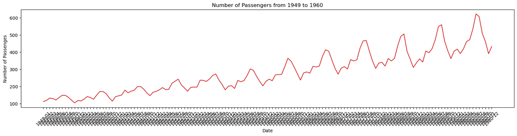

```python
def plot_df(df, x, y, title="", xlabel="Date", ylabel="Number of Passenges", dpi=100):
    plt.figure(figsize=(20,4), dpi=dpi)
    plt.plot(x, y, color='tab:red')
    plt.gca().set(title=title, xlabel=xlabel, ylabel=ylabel)
    plt.xticks(rotation=45)
    plt.show()

plot_df(df, x=df['Date'], y=df['Number of Passengers'], title="Number of Passengers from 1949 to 1960")
```

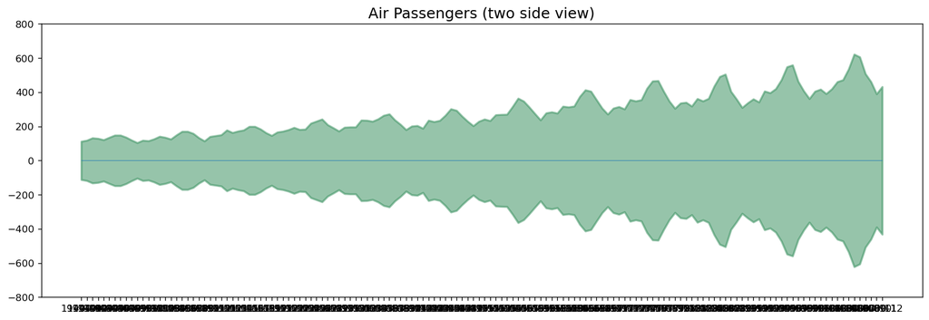

```python
x=df['Date'].values
y1=df['Number of Passengers'].values

#plot
fig, ax=plt.subplots(1,1, figsize=(16,5), dpi=120)
plt.fill_between(x, y1=y1, y2=-y1, alpha=0.5, linewidth=2, color='seagreen')
plt.ylim(-800,800)
plt.title("Air Passengers (two side view)", fontsize=15)
plt.hlines(y=0, xmin=np.min(df['Date']),xmax=np.max(df['Date']), linewidth=.5)
plt.show()
```

# Patterns in Time Series

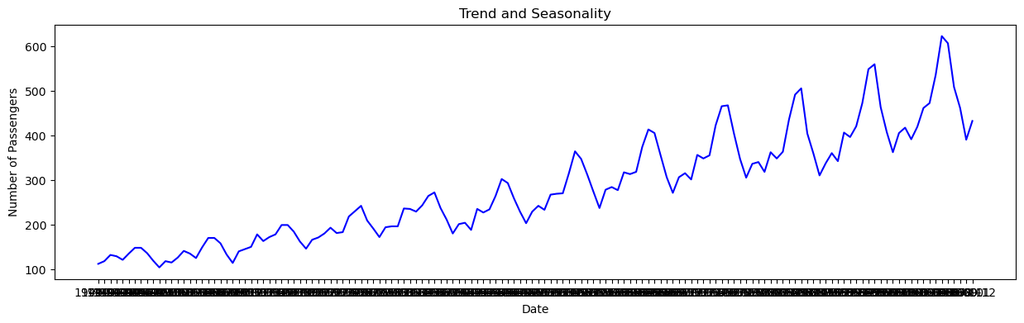

```python
# Trend and Seasonality
plt.figure(figsize=(15,4), dpi=100)
plt.plot(df['Date'], df['Number of Passengers'], color='blue')
plt.title("Trend and Seasonality")
plt.xlabel("Date")
plt.ylabel("Number of Passengers")
plt.show()
```

# 1. Stationary Time Series

**A time series is stationary if its statistical properties (mean, variance, autocorrelation) do not change over time.**

**Properties:**

- Constant mean (does not drift up or down).
- Constant variance (no increasing spread).
- Autocorrelation depends only on lag, not on time.

👉 In other words: The series looks statistically the same at all points in time.

# 2. Non-Stationary Time Series

**A time series is non-stationary if its statistical properties change over time.**

**Signs of Non-Stationarity:**

- Trend: mean increases or decreases over time.
- Changing variance: volatility increases/decreases.
- Seasonality: repeating patterns over fixed periods.

**Example:**

- Airline passengers data (trend ↑ + seasonality).
- Stock prices (variance changes over time).

**Why Stationarity is Needed**

**Most time series models assume constant mean, variance, and autocorrelation.**

- Non-stationary data → spurious results.
- Stationary data → models can learn meaningful patterns.

**Methods to Make a Time Series Stationary:**

**A. Differencing**

- Subtract the previous value from the current value to remove trends:
- Can do first-order differencing (lag 1) or second-order if needed.
- Removes linear trends.

**B. Log Transformation**

- Stabilizes variance if the series grows exponentially.

**C. Detrending**

- Fit a trend line (linear, polynomial, or moving average) and subtract it:

**D. Deseasonalizing**

- Remove seasonal component (from decomposition)

**E. Combination**

- Sometimes you need log + differencing or detrending + deseasonalizing to make it fully stationary.

# Decomposition of a time series

**Decomposition in time series means breaking down a time series into its underlying components to better understand its structure.**

**A typical time series is assumed to have 3 main components:**

- Trend (T) → Long-term movement (upward, downward, flat).
- Seasonality (S) → Repeating short-term patterns (daily, weekly, yearly cycles).
- Residual/Noise (R) → Irregular, random fluctuations that can’t be explained by trend/seasonality.

**🔹 Two Types of Decomposition**

**1. Additive Model**

- Y(t)=T(t)+S(t)+R(t)
- Seasonal variation is constant in size.
- Example: Monthly ice cream sales increase by about +200 units every summer, regardless of overall sales growth.

**2. Multiplicative Model**

- Y(t)=T(t)×S(t)×R(t)
- Seasonal variation scales with the trend.
- Example: Airline passengers — as the total number of passengers grows, the seasonal peaks and dips also get larger in absolute terms.

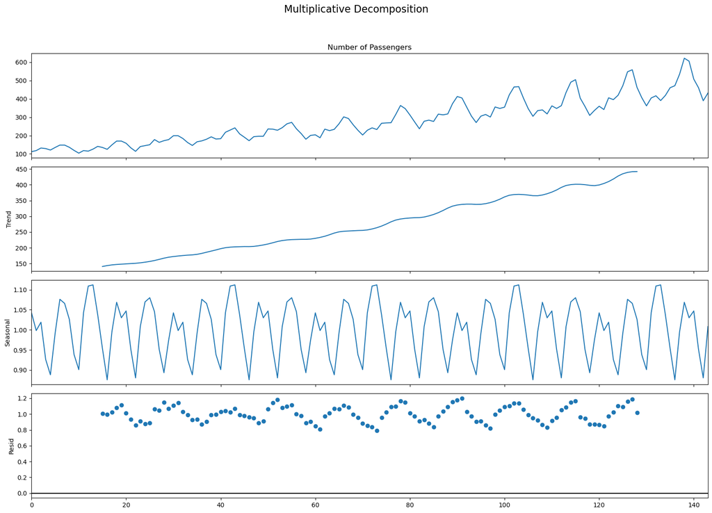

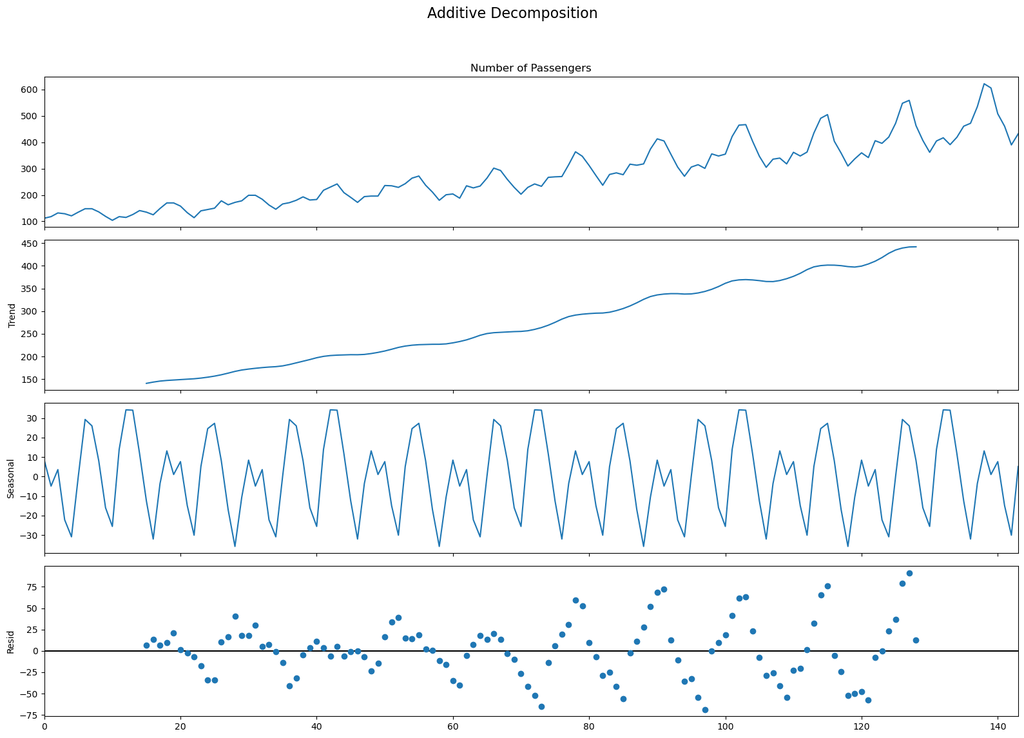

```python
from statsmodels.tsa.seasonal import seasonal_decompose
from dateutil.parser import parse

# Multiplicative Decomposition
multiplicative_decomposition= seasonal_decompose(df['Number of Passengers'], model='multiplicative', period=30)

# Additive Decomposition
additive_decomposition= seasonal_decompose(df['Number of Passengers'], model='additive', period=30)

# Plot
plt.rcParams.update({'figure.figsize': (16,12)})
multiplicative_decomposition.plot().suptitle('Multiplicative Decomposition', fontsize=16)
plt.tight_layout(rect=[0, 0.03, 1, 0.95])

additive_decomposition.plot().suptitle('Additive Decomposition', fontsize=16)
plt.tight_layout(rect=[0, 0.03, 1, 0.95])

plt.show()
```

# White Noise

**In time series, white noise is a sequence of random values that:**

- Have zero mean (average ≈ 0).
- Have constant variance (homoscedasticity).
- Have no autocorrelation (values are independent across time).

**In short we can say: White noise is a completely random series with no pattern. It’s used as the baseline to check whether your time series model has captured all useful information.**

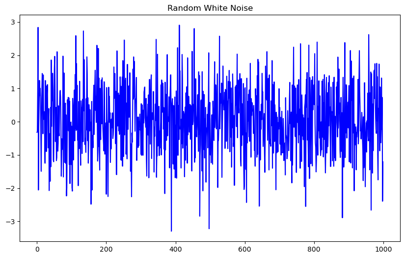

```python
# White noise
plt.figure(figsize=(10,6))
rand_numbers=np.random.randn(1000)
pd.Series(rand_numbers).plot(title='Random White Noise', color='blue')
```

# Detrend a Time Series

**Detrending a time series means removing the long-term trend component from the data, so that only the short-term variations (seasonality + residuals) remain.**

**Mathematically:**

- If a time series is: Y(t)=T(t)+S(t)+R(t)
- then detrending removes T(t): Y′(t)=Y(t)−T(t)

**🔹 Why do we detrend?**

- Stationarity requirement → Many time series models (like ARIMA) assume the series is stationary (no trend/constant mean).
- Focus on seasonality/irregularities → Helps analyze cycles and seasonal effects without trend bias.
- Comparisons → Makes it easier to compare multiple series that grow at different rates.

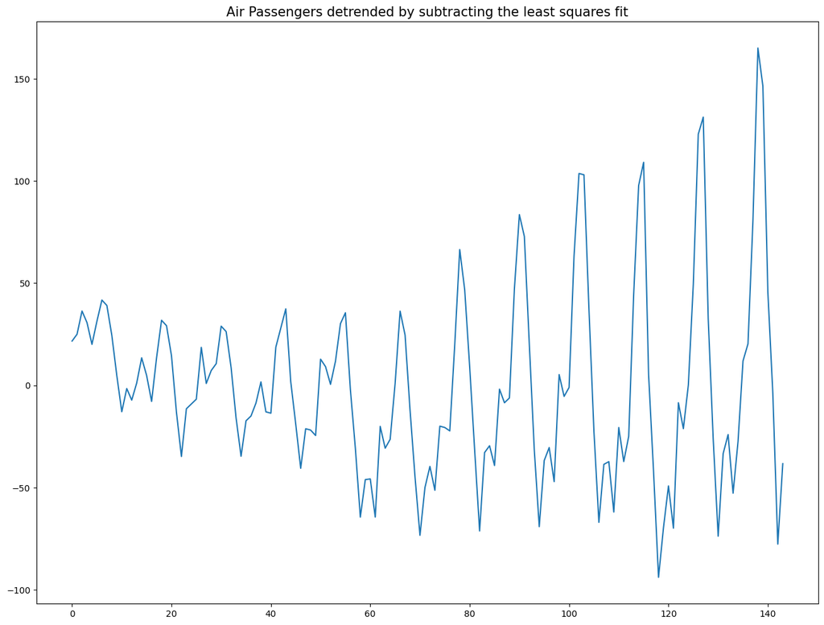

```python
# Detrend a Time Series
from scipy import signal
detrended=signal.detrend(df['Number of Passengers'].values)
plt.plot(detrended)
plt.title('Air Passengers detrended by subtracting the least squares fit', fontsize=15)
plt.figure(figsize=(8,6))
```

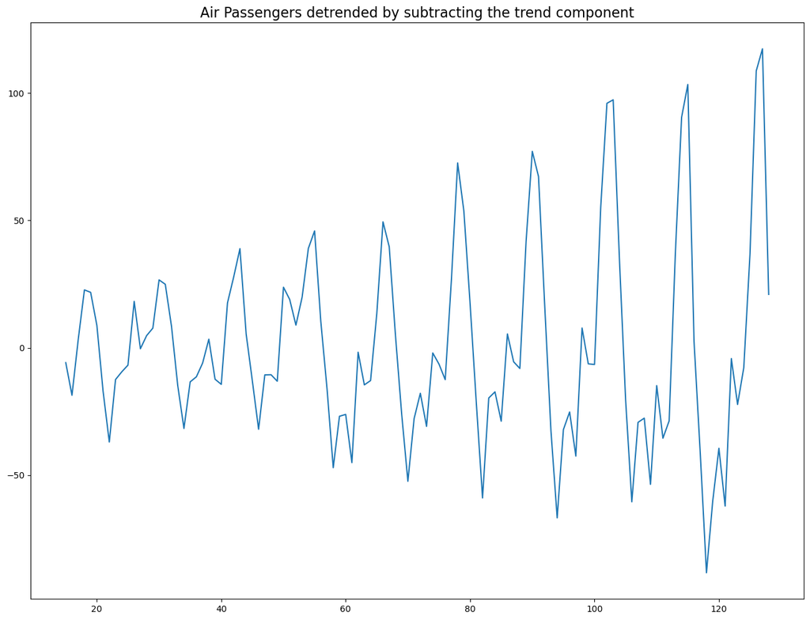

```python
# Subtracting the trend model
result_mul= seasonal_decompose(df['Number of Passengers'], model='multiplicative', period=30)
detrended= df['Number of Passengers'].values - result_mul.trend
plt.plot(detrended)
plt.title("Air Passengers detrended by subtracting the trend component", fontsize=16)
```

# Deseasonalize a time series

**Deseasonalizing (or deseasonalization) a time series means removing the seasonal component so that we can study the underlying trend and residuals more clearly.**

- If a time series is: Y(t)=T(t)+S(t)+R(t)(Additive model) or Y(t)=T(t)×S(t)×R(t)(Multiplicative model).
- then deseasonalizing removes S(t).

**Why do we deseasonalize?**

- To study the true trend without seasonal fluctuations.
- To make comparisons across periods.
- To prepare data for forecasting models that require stationary input (like ARIMA).
- To analyze cyclic or irregular movements without seasonal bias.

**Methods of Deseasonalization**

**1. Additive Model:--**

- Deseasonalized Value=Y(t)−S(t)

**2. Multiplicative Model**

- Deseasonalized Value=Y(t) / S(t)

👉 Choice depends on whether seasonality is constant (additive) or proportional to trend (multiplicative).

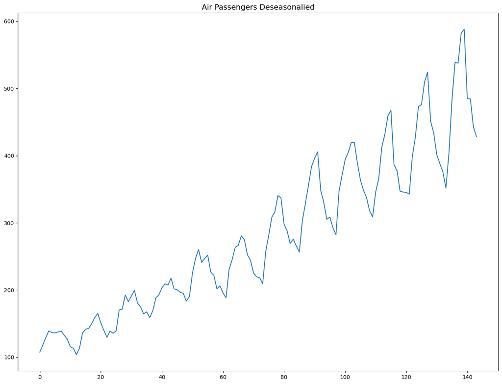

```python
# Deseasonalize a time series
deseasonalized=df['Number of Passengers'].values / result_mul.seasonal
plt.plot(deseasonalized)
plt.title("Air Passengers Deseasonalied", fontsize=14)
plt.show()
```

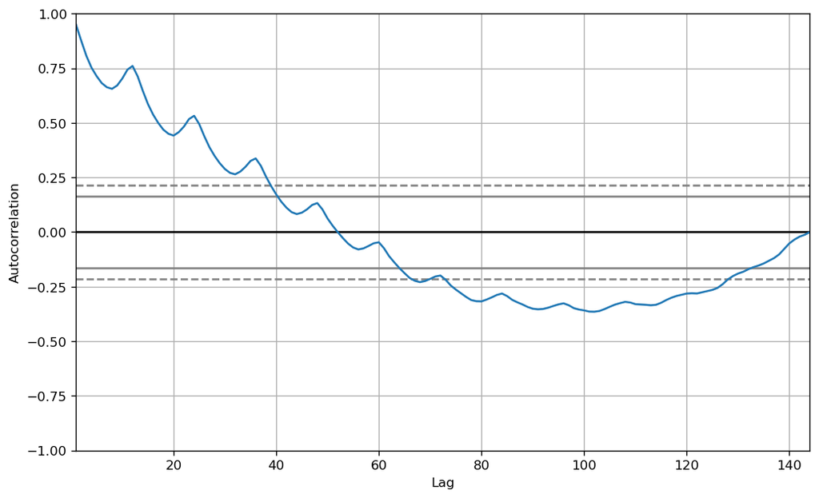

```python
# Test for seasonality
from pandas.plotting import autocorrelation_plot

plt.rcParams.update({'figure.figsize':(10,6), 'figure.dpi':120})
autocorrelation_plot(df['Number of Passengers'].to_list())
```

# Autocorrelaation and Partial Autocorrelation Function

**ACF measures how much current values depend on past values at different lags**

**PACF measures the “direct” correlation at lag k, without indirect effects from shorter lags.**

**Lag:**

In time series, a lag means shifting the data back by a certain number of time steps.

- Lag 1 → yesterday’s value (previous time step)
- Lag 2 → value from 2 days ago
- Lag k → value from k time steps earlier

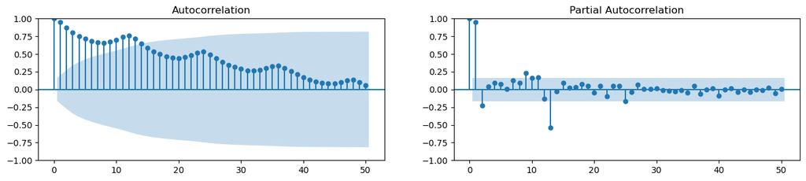

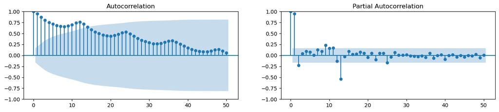

```python
from statsmodels.tsa.stattools import acf, pacf
from statsmodels.graphics.tsaplots import plot_acf, plot_pacf

fig, axes= plt.subplots(1,2, figsize=(16,3), dpi=100)
plot_acf(df['Number of Passengers'].to_list(), lags=50, ax=axes[0])
plot_pacf(df['Number of Passengers'].to_list(),lags=50, ax=axes[1])
```

# Lag Plots

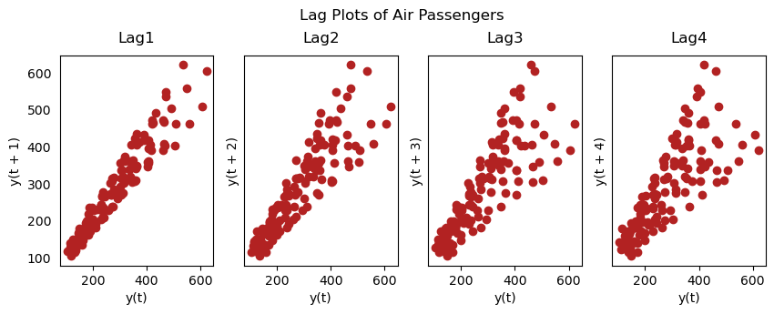

```python
from pandas.plotting import lag_plot
plt.rcParams.update({'ytick.left': False, 'axes.titlepad': 10})

fig, axes= plt.subplots(1, 4, figsize=(10,3), sharex=True, sharey=True, dpi=100)
for i, ax in enumerate(axes.flatten()[:4]):
    lag_plot(df['Number of Passengers'], lag=i+1, ax=ax, c='firebrick')
    ax.set_title("Lag" + str(i+1))

fig.suptitle("Lag Plots of Air Passengers", y=1.05)
plt.show()
```

# Granger Causality Test

**Granger causality tests whether past values of one time series improve the prediction of another, beyond what its own past values explain.**

```python
from statsmodels.tsa.stattools import grangercausalitytests
data= pd.read_csv("dataset.txt")
data['date']= pd.to_datetime(data['date'])
data['month']=data.date.dt.month
grangercausalitytests(data[['value', 'month']], maxlag=2)
```

```
Granger Causality
number of lags (no zero) 1
ssr based F test:         F=54.7797 , p=0.0000  , df_denom=200, df_num=1
ssr based chi2 test:   chi2=55.6014 , p=0.0000  , df=1
likelihood ratio test: chi2=49.1426 , p=0.0000  , df=1
parameter F test:         F=54.7797 , p=0.0000  , df_denom=200, df_num=1

Granger Causality
number of lags (no zero) 2
ssr based F test:         F=162.6989, p=0.0000  , df_denom=197, df_num=2
ssr based chi2 test:   chi2=333.6567, p=0.0000  , df=2
likelihood ratio test: chi2=196.9956, p=0.0000  , df=2
parameter F test:         F=162.6989, p=0.0000  , df_denom=197, df_num=2
```

[output not shown]